# Chapter 5: Dimensionality reduction techniques

```r
date()
```

```
## [1] "Wed Dec  1 10:13:17 2021"
```

```r
library(dplyr)
library(ggplot2)
library(GGally)
library(corrplot)
library(tidyr)
```

## 5.1 Data

The data set used here is drawn from Human Development Index and Gender Development Index. More information can be found from the [United Nations Development Programme’s webpage](http://hdr.undp.org/en/content/human-development-index-hdi). The prepared data set examined here consists of 155 observations (that is countries) of 8 variables.

*Description of the variables in the prepared data:*

- GNIperCap = Gross National Income per capita
- LifeExp = Life expectancy at birth
- ExpEdu = Expected years of schooling
- MatMortalityRate = Maternal mortality ratio
- AdoBirthRate = Adolescent birth rate
- FemalesParliament = Percetange of female representatives in parliament
- SecondEduRatio = Proportion of females with at least secondary education / Proportion of males with at least secondary education
- LabourRatio = Proportion of females in the labour force / Proportion of males in the labour force

The structure of the data and summaries of the variables are shown below.

```r
# download the data
human <- read.table("data/human.csv", sep = ";")

str(human)
```

```
## 'data.frame':    155 obs. of  8 variables:
##  $ GNIperCap        : int  64992 42261 56431 44025 45435 43919 39568 52947 42155 32689 ...
##  $ LifeExp          : num  81.6 82.4 83 80.2 81.6 80.9 80.9 79.1 82 81.8 ...
##  $ ExpEdu           : num  17.5 20.2 15.8 18.7 17.9 16.5 18.6 16.5 15.9 19.2 ...
##  $ MatMortalityRate : int  4 6 6 5 6 7 9 28 11 8 ...
##  $ AdoBirthRate     : num  7.8 12.1 1.9 5.1 6.2 3.8 8.2 31 14.5 25.3 ...
##  $ FemalesParliament: num  39.6 30.5 28.5 38 36.9 36.9 19.9 19.4 28.2 31.4 ...
##  $ LabourRatio      : num  0.891 0.819 0.825 0.884 0.829 ...
##  $ SecondEduRatio   : num  1.007 0.997 0.983 0.989 0.969 ...
```

```r
summary(human)
```

```
##    GNIperCap         LifeExp          ExpEdu      MatMortalityRate
##  Min.   :   581   Min.   :49.00   Min.   : 5.40   Min.   :   1.0
##  1st Qu.:  4198   1st Qu.:66.30   1st Qu.:11.25   1st Qu.:  11.5
##  Median : 12040   Median :74.20   Median :13.50   Median :  49.0
##  Mean   : 17628   Mean   :71.65   Mean   :13.18   Mean   : 149.1
##  3rd Qu.: 24512   3rd Qu.:77.25   3rd Qu.:15.20   3rd Qu.: 190.0
##  Max.   :123124   Max.   :83.50   Max.   :20.20   Max.   :1100.0
##   AdoBirthRate    FemalesParliament  LabourRatio     SecondEduRatio
##  Min.   :  0.60   Min.   : 0.00     Min.   :0.1857   Min.   :0.1717
##  1st Qu.: 12.65   1st Qu.:12.40     1st Qu.:0.5984   1st Qu.:0.7264
##  Median : 33.60   Median :19.30     Median :0.7535   Median :0.9375
##  Mean   : 47.16   Mean   :20.91     Mean   :0.7074   Mean   :0.8529
##  3rd Qu.: 71.95   3rd Qu.:27.95     3rd Qu.:0.8535   3rd Qu.:0.9968
##  Max.   :204.80   Max.   :57.50     Max.   :1.0380   Max.   :1.4967
```

The graphical overview of the data is presented below. The scatter plot matrix shows the distributions of the variables and illustrates their relationship. A better overview of the relationship between the variables is provided by the correlation matrix, which shows that many of the variables are highly correlated with each other. The correlation coefficients vary from 1 to -1. A positive coefficient indicates that high values of variable ‘X’ are associated with the high values of variable ‘Y’. Respectively negative coefficient indicates that high values of ‘X’ are associated with low values of ‘Y’.

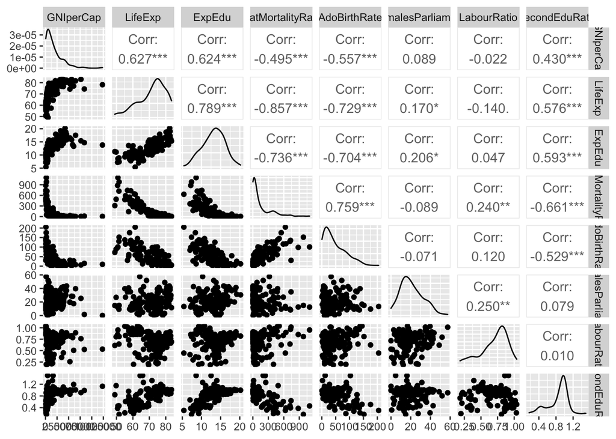

```r
# scatter plot matrix using ggplot2 and GGally -packages
ggpairs(human, lower = list(combo = wrap("facethist", bins = 20)))
```

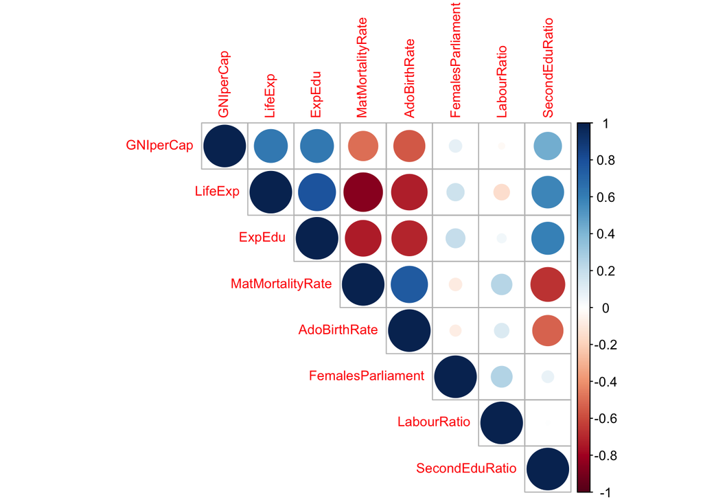

```r
# correlation matrix
cor(human) %>%
  corrplot(method = "circle", type = "upper", cl.pos = "r", tl.cex = 0.8)
```

## 5.2 Principal Component Analysis

Next, I will perform principal component analysis (PCA) on the human data: first with unstandardized data and after that with standardized data set.

### 5.2.1 Unstandardized data

```r
# PCA with SVD method (unstandardized data)
pca_human_ustd <- prcomp(human)
# summary of PCA results
smry <- summary(pca_human_ustd)
smry
```

```
## Importance of components:
##                              PC1      PC2   PC3   PC4   PC5   PC6    PC7    PC8
## Standard deviation     1.854e+04 185.5219 25.19 11.45 3.766 1.566 0.1912 0.1591
## Proportion of Variance 9.999e-01   0.0001  0.00  0.00 0.000 0.000 0.0000 0.0000
## Cumulative Proportion  9.999e-01   1.0000  1.00  1.00 1.000 1.000 1.0000 1.0000
```

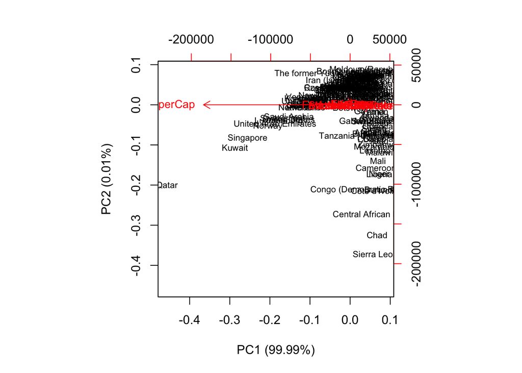

```r
#rounded percentages of variance captured by each PC
pca_pr <- round(1*smry$importance[2, ] * 100, digits = 2)
# create object pc_lab (variance captured) to be used as axis labels
pc_lab <- paste0(names(pca_pr), " (", pca_pr, "%)")

# biplot of the resuts
biplot(pca_human_ustd,
       choices = 1:2,
       cex = c(0.7, 0.9),
       col = c("black", "red"),
       xlab = pc_lab[1], ylab = pc_lab[2])
```

The results from PCA performed with unstandardized data are shown above in the summary table and graphically in the biplot. They clearly show that the first principal component captures (misleadingly) almost all variance (99.99%), which is due to the use of unstandardized data. PCA is sensitive to the relative scaling of the data and it assumes that variables with larger variance are more important than those with smaller variance, which is not the case here and, thus the data must be standardized before performing PCA.

### 5.2.2 Standardized data

The results from PCA of standardized data are presented below. Now the first principal component captures about 54 percent of the variance and the second component about 16 percent. In the biplot the arrows can be interpreted as follows:

- the angle between the arrows illustrates the correlation between the variables
- the angle between a variable and a PC axis illustrate the correlation between the two
- the length of the arrow is a proportional to the standard deviation of the variable

From the figure one can notice, for instance, that GNI per capita, life expectancy, expected education and gender ratio in the secondary education are all highly ‘positively’ correlated with each other. Respectively, maternal mortality is positively correlated with adolescence birth rate and these two are negatively correlated with the variables mentioned in the previous sentence (e.g. maternal mortality is negatively correlated with life expectancy). Moreover, the figure illustrate that all these above mentioned features are contributing to the first principal component. Instead, the variables FemalesParliament and LabourRatio are contributing to the second principal component and the vertical arrows illustrate that the share of women in the parliament correlates positively with the labour ratio between the genders.

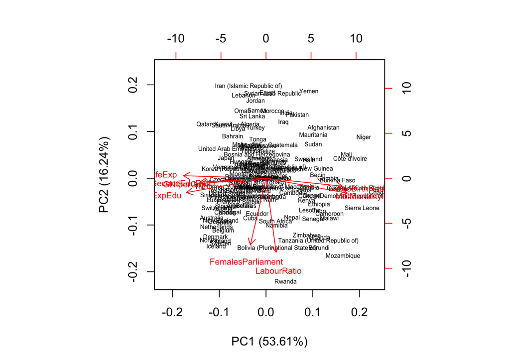

```r
# standardize the human data and save it as data frame
human_std <- as.data.frame(scale(human))
# PCA with SVD method (standardized data)
pca_human_std <- prcomp(human_std)
# summary of PCA results
smry_std <- summary(pca_human_std)

#rounded percentages of variance captured by each PC
pca_pr_std <- round(1*smry_std$importance[2, ] * 100, digits = 2)
# create object pc_lab (variance captured) to be used as axis labels
pc_lab_std <- paste0(names(pca_pr_std), " (", pca_pr_std, "%)")

# biplot of the resuts
biplot(pca_human_std,
       choices = 1:2,
       cex = c(0.5, 0.7),
       col = c("black", "red"),
       xlab = pc_lab_std[1], ylab = pc_lab_std[2])
```